# problem set 8 template

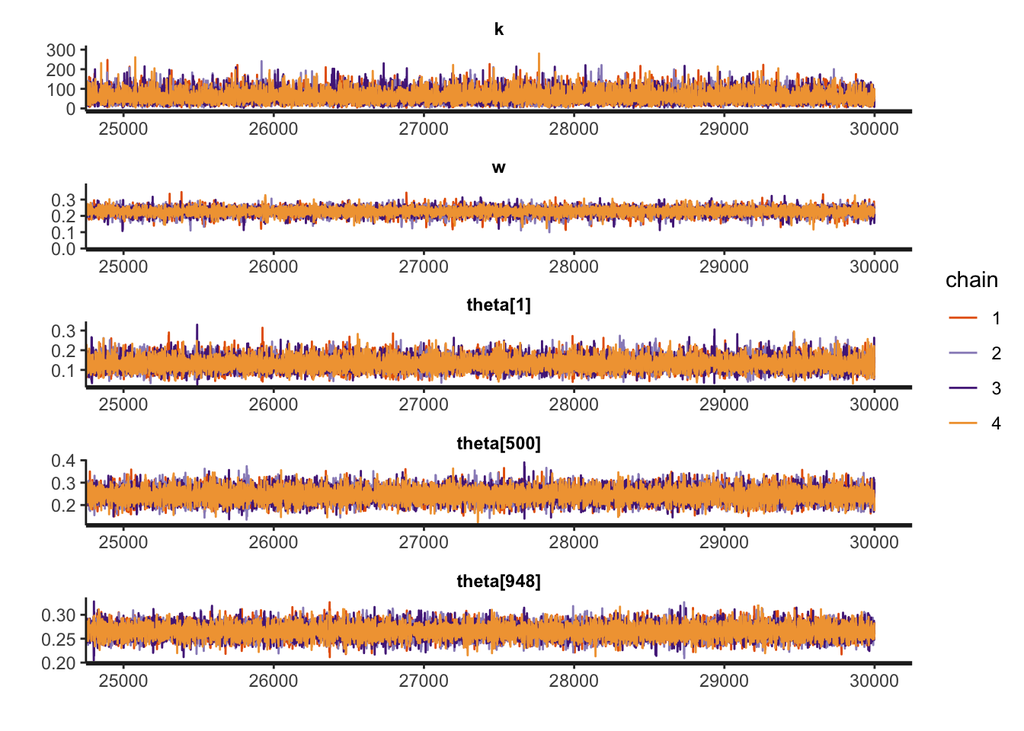

```r
#Inspect the trace plots for both hyperparameters, for the field position mode
#and concentrations, and for the theta of the 1st, 500th, and 948th player in
#the dataset.
traceplot(fit, inc_warmup = FALSE, nrow = 5, window = c(25000, 30000),
          pars = c("k", "w", "theta[1]", "theta[500]", "theta[948]"))
```

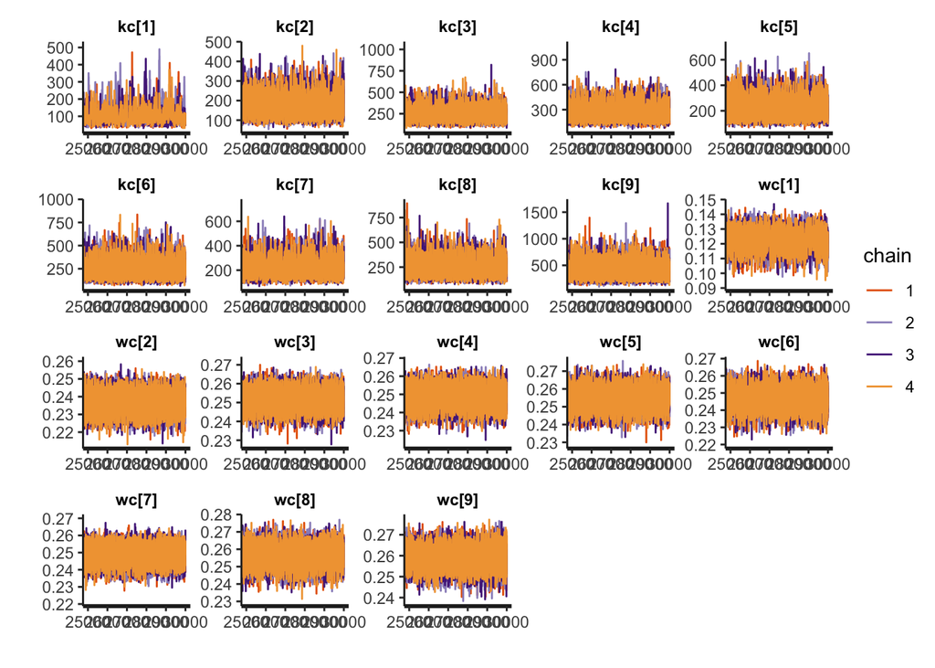

```r
traceplot(fit, inc_warmup = FALSE, window = c(25000, 30000),
          pars = c("kc", "wc"))
```

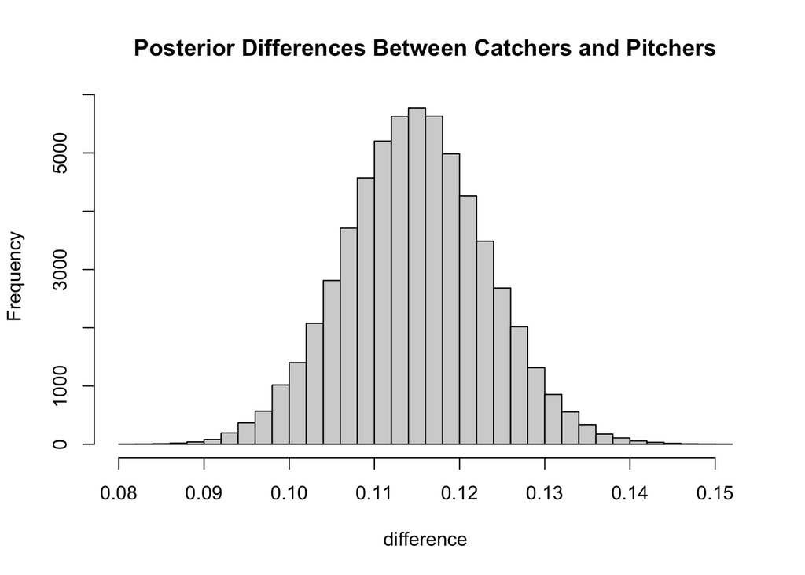

```r
samples = extract(fit)
w_catcher = samples$wc[, 2]
w_pitcher = samples$wc[, 1]
difference = w_catcher - w_pitcher
hist(difference, breaks = 40, main="Posterior Differences Between Catchers and Pitchers")
```

```r
library(bayestestR)
hdi(difference)
```

```
## 95% HDI: [0.10, 0.13]
```

```r
paste("|P(w_catcher > w_pitcher): ", mean(difference > 0))
```

```
## [1] "|P(w_catcher > w_pitcher):  1"
```

## Step 4

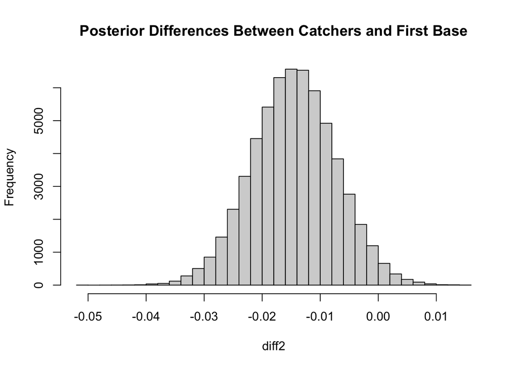

```r
w_catcher = samples$wc[, 2]
w_first_base = samples$wc[, 3]
diff2 = w_catcher - w_first_base
hist(diff2, breaks = 40, main="Posterior Differences Between Catchers and First Base")
```

```r
hdi(diff2)
```

```
## 95% HDI: [-0.03,  0.00]
```

```r
paste("|P(w_catcher > w_first_base): ", mean(diff2 > 0))
```

```
## [1] "|P(w_catcher > w_first_base):  0.0220333333333333"
```

## step 5

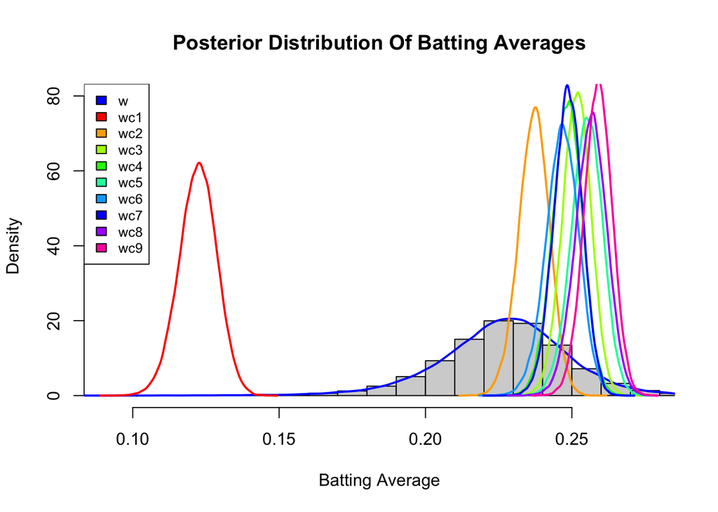

```r
hist(samples$w, freq = FALSE, xlim = c(min(samples$wc), max(samples$wc)), ylim=c(0, 80),
     main = "Posterior Distribution Of Batting Averages",
     xlab = "Batting Average", breaks=50)

lines(density(samples$w), lwd = 2, col = "blue")
colors = rainbow(9)
for (i in 1:9) {
  lines(density(samples$wc[,i]), lwd = 2, col = colors[i])
}

legend("topleft", legend = c("w", paste("wc", 1:9, sep = "")), fill = c("blue", colors), cex = 0.8)
```

This is because w is only informed by nine parameters wc(1:9) whereas each wc is informed by way more data points relating to the player’s positions. Therefore, as wc has more data points informing it, it has a tighter posterior compared to w which has 9.

## step 6

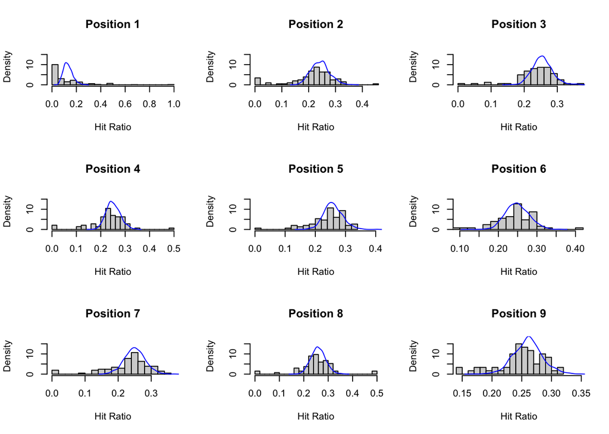

```r
par(mfrow=c(3,3))

for (i in 1:9) {
  smpw = sample(samples$wc[,i], 10000)
  smpk = sample(samples$kc[,i], 10000)
  hit_preds = rbeta(1000, smpw * smpk + 1, (1 - smpw) * smpk + 1)
  hits_ratio = hits[position == i] / atbat[position == i]

  # Plot the histogram of observed hit ratios
  hist(hits_ratio, probability = TRUE, main = paste("Position", i),
       xlab = "Hit Ratio", ylab = "Density", xlim = range(c(hits_ratio, hit_preds)),
       ylim=c(0, 18), breaks=20)

  lines(density(hit_preds), col = "blue")
}
```

## step 7

The exchangeability assumption does not hold here as the pitcher does not seem related to the others as pitcher batting average is clearly an outlier here. The density for pitchers is very far from the other densities of other positions suggesting that pitchers have distinct batting average therefore we can’t treat them as exchangeable with other positions.

# Question 2

## step 1

```r
fit_2 = stan("ps_8_2.stan", iter=25000, chains=4,
           data=list(N = N, atbat = atbat, position = position, hits = hits))
```

```
## Trying to compile a simple C file
```

[output not shown]

## step 2

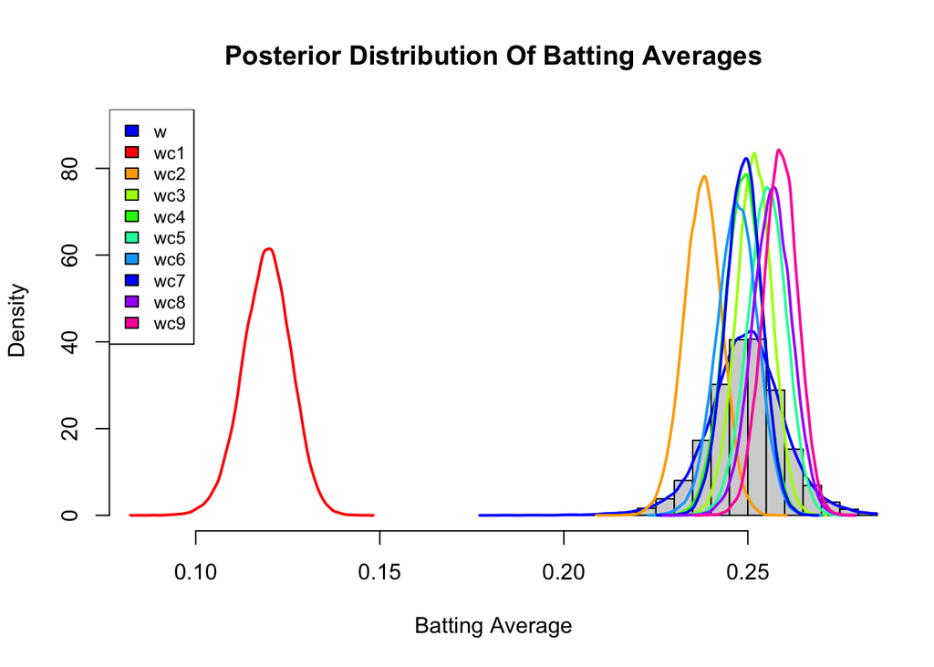

```r
samples_2 = extract(fit_2)
hist(samples_2$w, freq = FALSE, xlim = c(min(samples_2$wc), max(samples_2$wc)), ylim=c(0, 90),
     main = "Posterior Distribution Of Batting Averages",
     xlab = "Batting Average", breaks=50)

lines(density(samples_2$w), lwd = 2, col = "blue")
colors = rainbow(9)
for (i in 1:9) {
  lines(density(samples_2$wc[,i]), lwd = 2, col = colors[i])
}

legend("topleft", legend = c("w", paste("wc", 1:9, sep = "")),
       fill = c("blue", colors), cex = 0.8)
```

## step 3

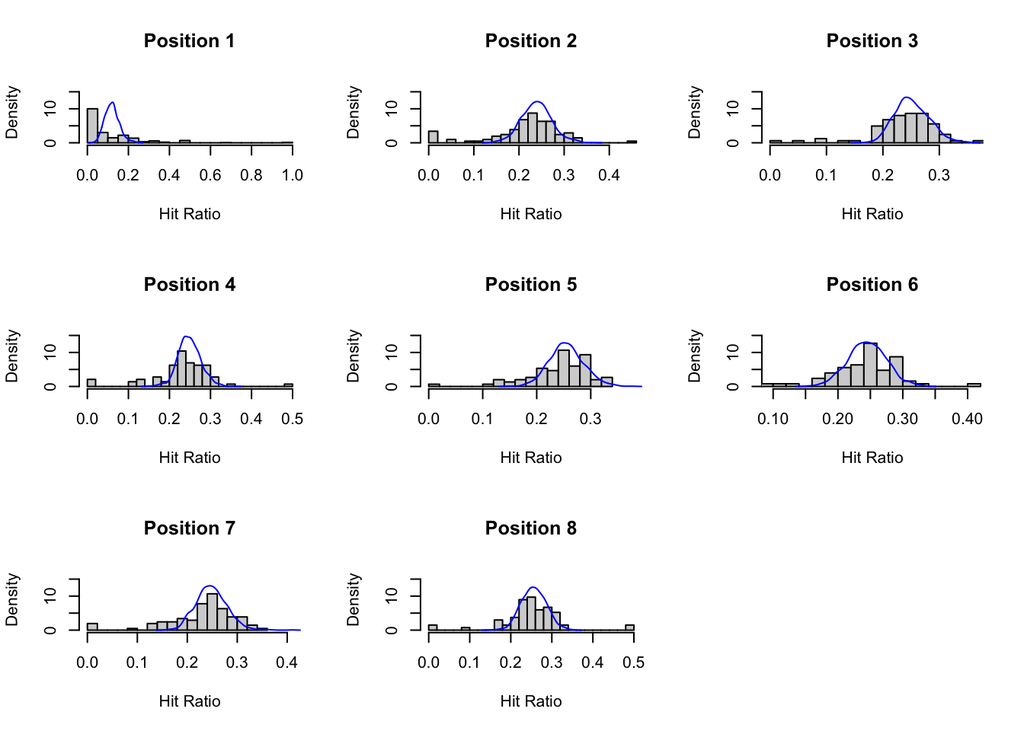

```r
par(mfrow=c(3,3))

for (i in 1:8) {
  smpw_2 = sample(samples_2$wc[,i], 10000)
  smpk_2 = sample(samples_2$kc[,i], 10000)
  hit_preds_2 = rbeta(1000, smpw_2 * smpk_2, (1 - smpw_2) * smpk_2)
  hits_ratio_2 = hits[position == i] / atbat[position == i]

  # Plot the histogram of observed hit ratios
  hist(hits_ratio_2, probability = TRUE, main = paste("Position", i),
       xlab = "Hit Ratio", ylab = "Density", xlim = range(c(hits_ratio_2, hit_preds_2)),
       ylim=c(0, 18), breaks=20)

  lines(density(hit_preds_2), col = "blue")
}
```

## step 4.

The hyper parameter w already has very few data points influencing it hence removing one of these data points would lead to a drastic change in w. Furthermore, the pitcher had the most variance compared to other position’s batting average as the position has the furthest batting average compared to the rest therefore removing it would lead to this tighter posterior for w as all of the other positions were pretty close in batting averages as seen in step 2. The predictive checks stay the same because looking at step 2 our posteriors for wc(1:9) stay they same hence sampling from them should give the same result.